# Dobutamine Stress Echocardiography and the Prediction of Cardiac Events

# 6 Task 6: The Variables

There are 13 variables in the `stressEcho` data set.

1. **patient**
   - This is a patient identification code, ranging from 1-558.
2. **age**
   - This is the patient’s age at baseline in years (baseline = the time when they underwent dobutamine stress echocardiography.)
3. **female**
   - This is an indicator (1 = female, 0 = male) of the patient’s sex.
4. **bhr**
   - This is the patient’s basal heart rate in beats per minute. Basal means baseline, for our purposes. The basal heart rate is the normal resting heart rate of the patient.
5. **basebp**
   - This is the patient’s basal systolic blood pressure, in millimeters of mercury.
6. **baseEF**
   - This is the patient’s basal cardiac ejection fractionm expressed as a percentage. It describes how well the heart’s left ventricle pumps blood with each heart beat. Specifically, it measures the percentage of blood that is being pumped out of the left ventricle of the heart (the main pumping chamber) with each contraction.
7. **dose**
   - This describes the dose of dobutamine given to the patient in ug/kg/min.
8. **hx_smoking**
   - This characterizes each patient’s smoking history, as either a smoker (current or past) or non-smoker.
9. **chestpain_c**
   - This indicates whether the patient experienced chest pain (1 = yes, 0 = no) during the dobutamine stress echocardiogram.
10. **ecg**
    - This indicates the results of a resting echocardiogram as either Normal, Equivocal, or MI. MI indicates that there were signs of a heart attack. Equivocal means that the results are somewhat ambiguous.
11. **SE_res**
    - This indicates the results of a stress echocardiogram as either Positive or Negative. While a negative test can be taken more often at face value, a positive result will usually lead to a more detailed follow-up.
12. **dobEF**
    - This indicates the patient’s ejection fraction while on dobutamine. This will be our outcome for a linear regression model.
13. **event**
    - This is a composite outcome. A patient experiences the “event” outcome if they experience any of four outcomes during the 12 months following the dobutamine stress echocardiography: death, myocardial infarction, PTCA (Percutaneous transluminal coronary angioplasty, which is a minimally invasive procedure to open up blocked coronary arteries) or CABG (Coronary artery bypass grafting, which is a surgical procedure to improve blood flow to the heart.)

# 7 Task 7: Linear Model Plans

We will predict the quantitative outcome **dobEF** using some combination of the following eight variables:

- `age`
- `female`
- `bhr`
- `basebp`
- `baseEF`
- `hx_smoking`
- `dose`
- `ecg`

In advance, we might anticipate that `baseEF` and `dose` will be key predictors, although I don’t claim to know much about it. The cardiologists in the room will have better insight.

## 7.1 Spearman $\rho^2$ Plot

A Spearman $\rho^2$ plot suggests that `baseEF` is important, but it’s not clear that `dose` will be particularly useful. In this example, note that we fit this plot without accounting for the missing values of any of these predictors, so that may have some effect.

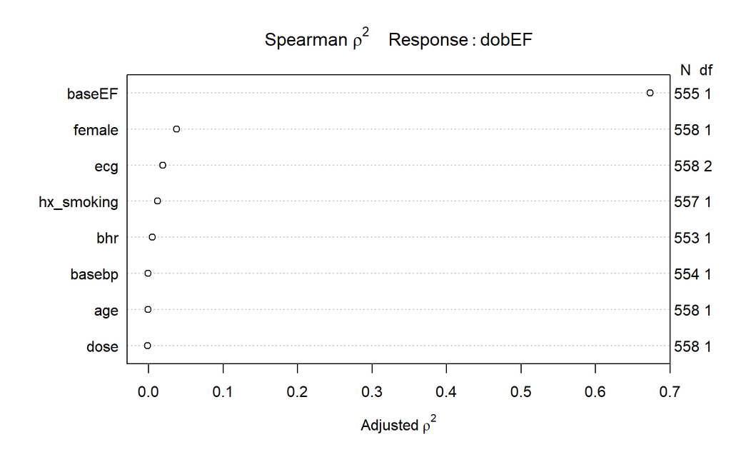

```r
plot(spearman2(dobEF ~ age + female + bhr + basebp + baseEF + hx_smoking + dose +
    ecg, data = stressEcho))
```

# 8 Task 8: Logistic Model Plans

We will predict the binary outcome **event** using some combination of the following ten variables:

- `age`
- `female`
- `bhr`
- `basebp`
- `baseEF`
- `dobEF`
- `hx_smoking`
- `ecg`
- `chestpain_c`
- `SE_res`

Here, knowing essentially nothing about it, we might expect that ejection fraction and `ecg` status would be of primary importance. Again, the cardiologists in the room will have better insight.

## 8.1 Spearman $\rho^2$ Plot

A Spearman $\rho^2$ plot certainly seems to back up the notion that the ejection fraction information and `ecg` status are important, but the `SE_res` is even more important. Of course, that makes sense. Again, here we fit this plot without accounting for missing predictor values.

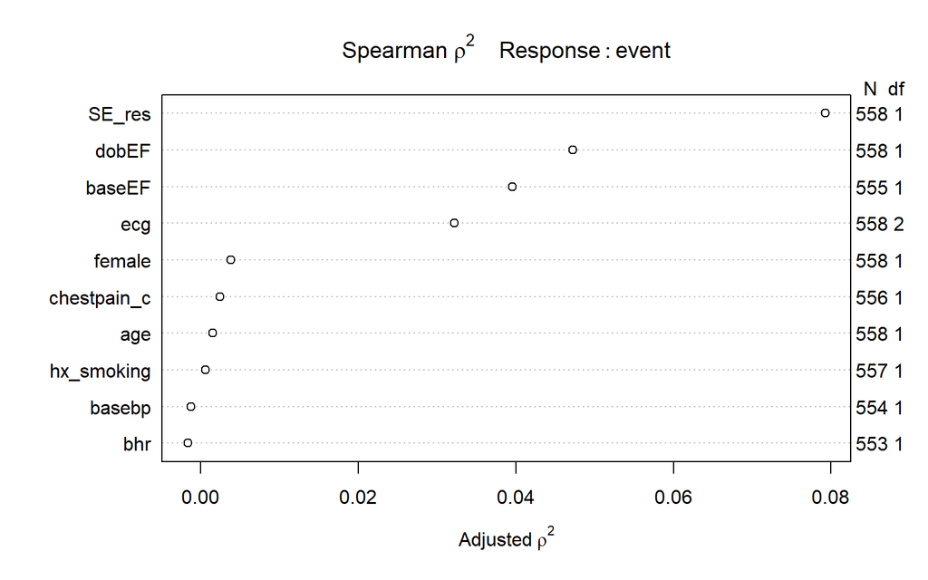

```r
plot(spearman2(event ~ age + female + bhr + basebp + baseEF + dobEF + hx_smoking +
    ecg + chestpain_c + SE_res, data = stressEcho))
```

# 9 Task 9: Affirmation

This data set meets all requirements specified in the project instructions.

Thomas E. Love for 432

2018-01-16 11:04:04